# Movies’ Budgets and Revenues

An extract of a little over forty-five thousand films was recently used to analyse the budget and revenues of movies. The data was sourced from [The Movie Database](https://www.themoviedb.org), a community-built database of movies and TV shows.

# Films with the highest budget and revenue

It seems like every week there are breathless announcements in the entertainment news, that the latest blockbuster has broken some kind of record. Which films had the highest budgets?

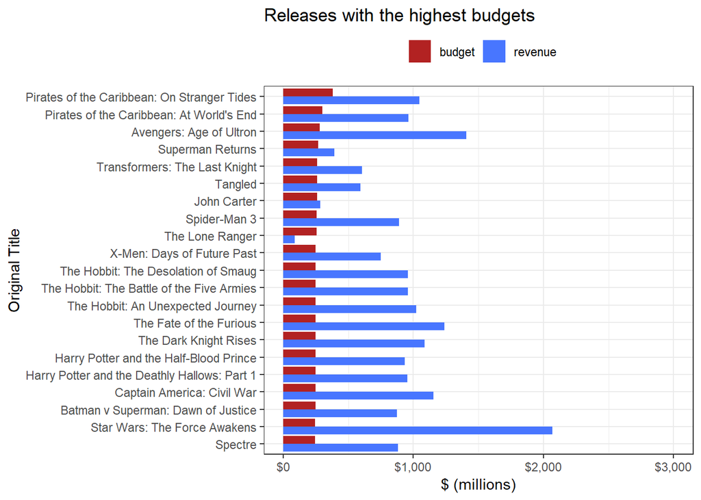

The highest budget film in the dataset is *Pirates of the Caribbean: On Stranger Tides*, which cost $380 million to make. It did pay off, though; the film had a revenue of $1 billion from the box office. On the other hand, *The Lone Ranger* earned a paltry $90 million revenue from its $255 million dollar budget.

Therefore, high budgets don’t always translate to large amounts of money coming in. Which films had the highest revenues?

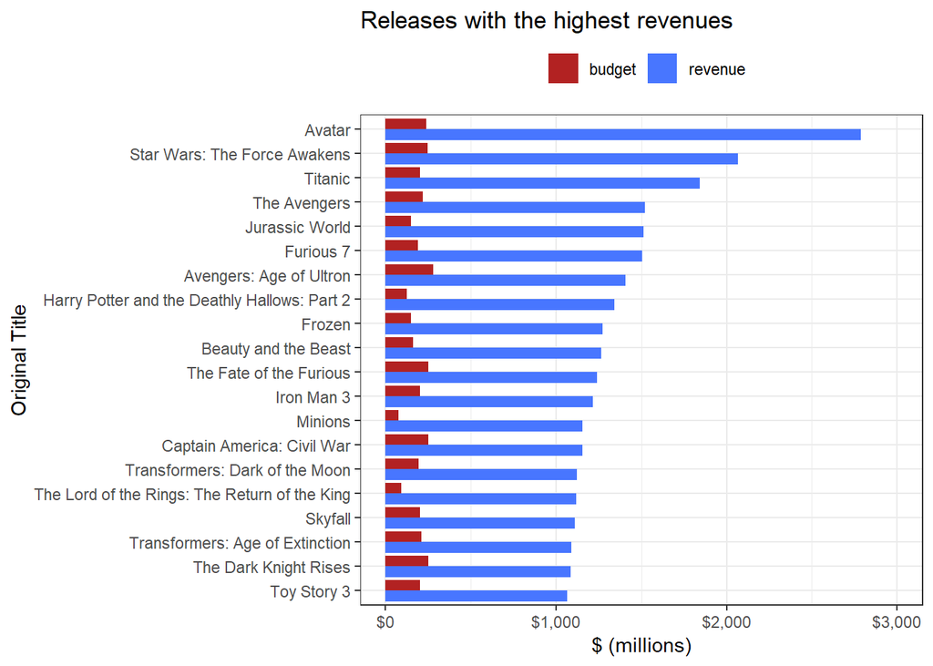

The highest revenue film was *Avatar*, which made $2.8 billion. Interestingly, there is very little crossover between the two charts; high budgets don’t always translate to high revenues.

# Return on Investment (ROI)

So, if high budgets don’t give high revenues, what does? Here are the films with the highest return on investment (`revenue / budget`) in the dataset.

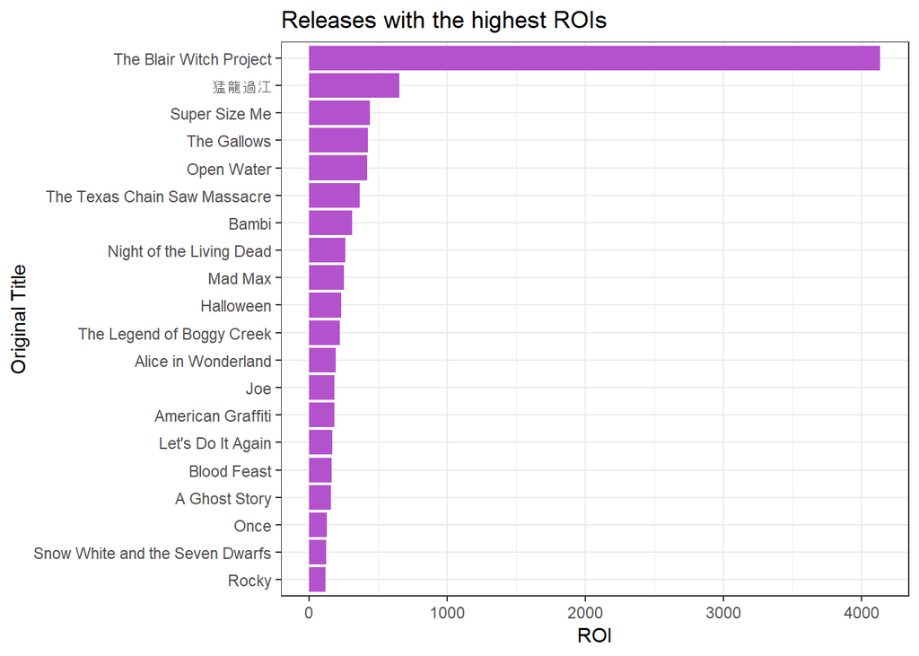

Obviously, the major outlier here is *The Blair Witch Project*, which made $250 million off its budget of $60 thousand. It’s worth noting that a number of other films in this list are also horror movies; it seems they’re cheap to make and sometimes become cult classics.

# Genres

What film genres have the highest budgets? Revenues? Here’s a breakdown by genre.

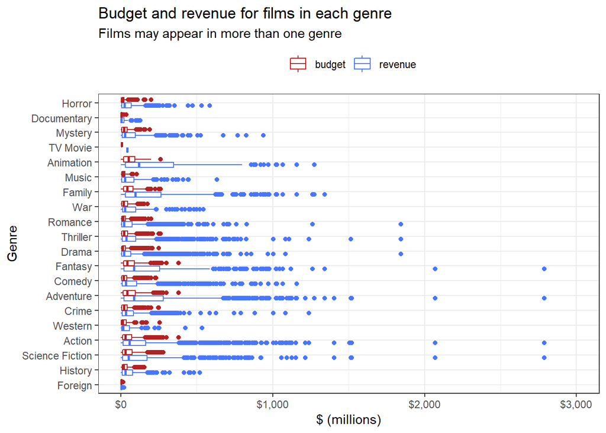

This is sorted by average ROI, so the genres where ROI tends to be higher are Horror, Documentary and Mystery. Plotting ROI directly looks like this:

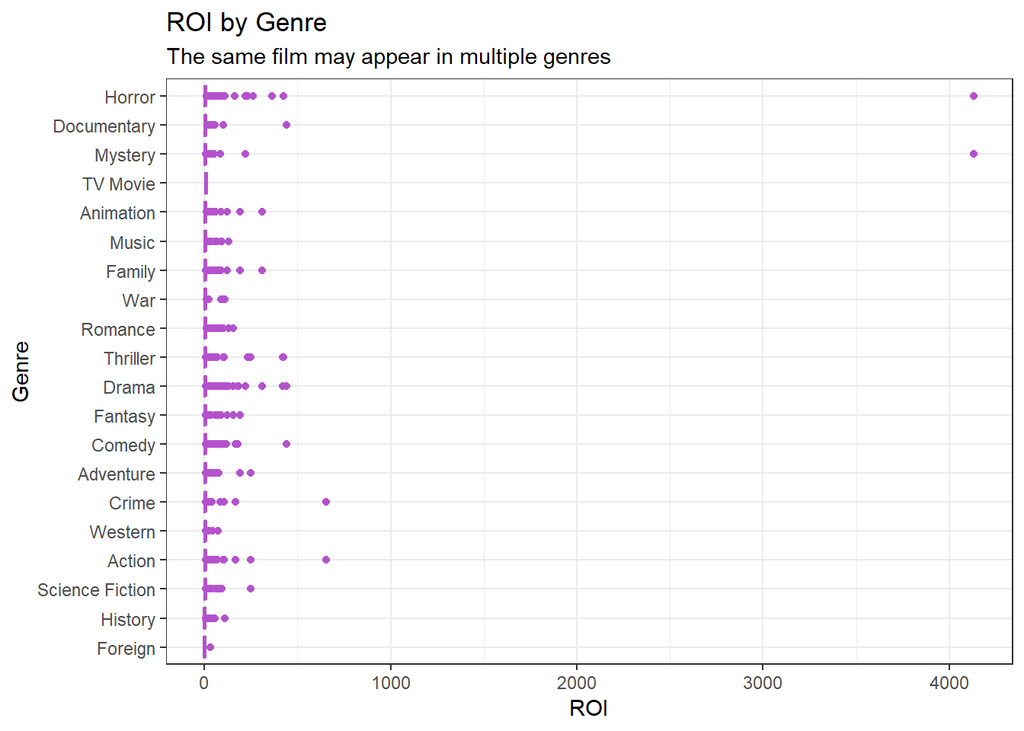

That outlier on the Horror and Mystery lines is *The Blair Witch Project* again. It’s likely its high ROI value is skewing the overall averages for those two genres, which is partially why they are so high. Here’s the same chart, zoomed to <= 50x ROI.

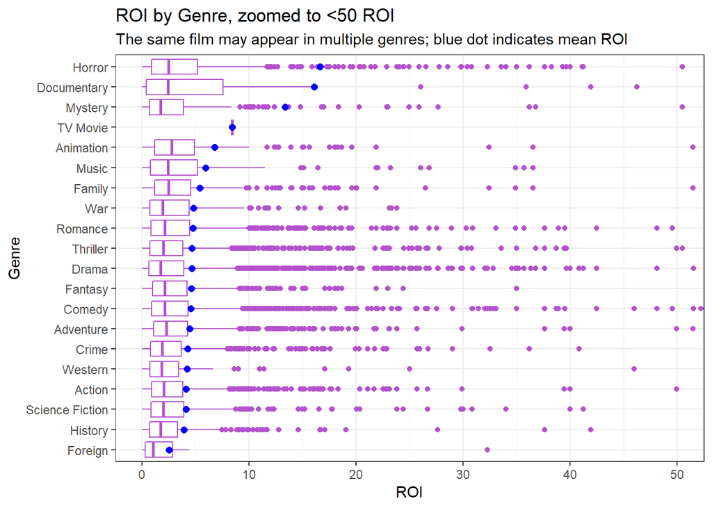

The zoomed in chart shows that it’s at least partially that one film pulling the Horror and Mystery genres’ ROIs up so high; the interquartile ranges of the boxplots demonstrate that Documentary has a higher 75th percentile than either. ROI is still strong for Horror and Mystery overall, but those genres aren’t the guaranteed wins that might be implied by a simple average.

# Conclusion

In general, the films that make the most revenue are the ones with a significant budget, but generally not the *most* investment. Yet outliers such as *The Blair Witch Project* buck the trend and demonstrate that even lower-budget films can be smash hits in the right circumstances, while *The Lone Ranger* shows that higher-budget films can still flop.

# Further reading

This was an edited excerpt from a more general exploration of this dataset. If you wish to read the full analysis, it is available [here](http://rpubs.com/mm-c/movies).